# Table of Contents

- 1. **Introduction**
- 2. **Setup**
- 3. **Data**
- 4. **Station 1: Burhanpur**
  - 4.1 **EDA**
    - 4.1.1 Feature Engineering
    - 4.1.2 Summary statistics
    - 4.1.3 Correlation analysis
  - 4.2 **Modeling**
    - 4.2.1 M1 - 60:40 split
    - 4.2.2 M2 - 70:30 split
    - 4.2.3 M3 - 80:20 split
    - 4.2.4 Performance evaluation
    - 4.2.5 Best-fit model selection
    - 4.2.6 Final Model - Burhanpur
- 5. **Station 2: Yerli**
  - 5.1 **EDA**
    - 5.1.1 Feature Engineering
    - 5.1.2 Summary statistics
    - 5.1.3 Correlation analysis
  - 5.2 **Modeling**
    - 5.2.1 M1 - 60:40 split
    - 5.2.2 M2 - 70:30 split
    - 5.2.3 M3 - 80:20 split
    - 5.2.4 Performance evaluation
    - 5.2.5 Best-fit model selection
    - 5.2.6 Final Model - Yerli
- 6. **Conclusion**

# **1. Introduction**

This is a re-implementation of a scientific study titled:

"[*Data-driven modelling framework for streamflow prediction in a physio-climatically heterogeneous river basin*](https://doi.org/10.1007/s00500-021-05585-9)" - Sharma et al. (2021)

The original study proposed a Model Tree (MT)-based data-driven approach for streamflow prediction in the Tapi river basin in India.  
A total of 72 model configurations were developed per gauging station by varying input variable combinations, Model Tree variants, and calibration–validation data splits. The study utilized correlation and mutual information analyses to identify relevant hydrometeorological predictors and evaluated model performance using multiple statistical metrics. Additionally, a sensitivity analysis was conducted to examine the impact of smoothing, pruning, and data partitioning on model outputs.

This re-implementation aims to follow the methodology outlined in the original work, validate the results and assess the reproducibility and robustness of the proposed framework.

# **2. Setup**

```python
import numpy as np
import pandas as pd
pd.set_option('display.max_columns', None)

import matplotlib.pyplot as plt
import seaborn as sns

import weka.core.jvm as jvm
jvm.start(logging_level=0)
print("Java Virtual Machine started.")

from weka.classifiers import Classifier
from sklearn.metrics import root_mean_squared_error, r2_score, mean_absolute_error
from src.utils import *
```

```
Java Virtual Machine started.
```

# **3. Data**

```python
def load_data(file_path, **kwargs):
    defaults = {'parse_dates': ['Date'], 'usecols': ['Date', 'Rt', 'Qt']}
    params = {**defaults, **kwargs}
    return pd.read_csv('../data/' + file_path, **params)
```

```python
bur_full = load_data('Burhanpur.csv')
yer_full = load_data('Yerli.csv')
```

**About the datasets:**

The data primarily consists of only two parameters: daily lumped rainfall depth 'Rt' (in mm) and daily streamflow discharge 'Qt' (in m³/s), for two stream gauging stations — Burhanpur and Yerli, in Burhanpur and Purna sub-catchments respectively, in the Upper Tapi Basin, for the duration of 1973 to 2013 (for monsoon periods only — from 01 June to 30 September (4 months) for each year).

- The daily rainfall records for the 53 rain gauge stations across the Tapi basin for duration 1973–2013 were collected from India Meteorological Department (IMD), Pune. These records are then used to compute the lumped rainfall for a catchment.
- The daily streamflows at Burhanpur and Yerli stream gauging stations for the same period 1973–2013 were collected from Tapi Division, Central Water Commission (CWC), Surat.

```python
# DataFrame for storing metrics
metrics = {
    'RMSE': root_mean_squared_error,
    'FSE': fractional_standard_error,
    'R2': r2_score,
    'MAE': mean_absolute_error,
    'NSE': nash_sutcliffe_efficiency,
    'MB': multiplicative_bias,
    'POD': probability_of_detection,
    'FA': false_alarm_rate,
    'RSR': rmse_to_std_ratio,
    'MMR': mae_to_mean_ratio,
    'MARE': mean_absolute_relative_error
}

train_metrics = [m for m in metrics.keys() if m != 'MARE']
test_metrics = metrics.keys()

col_index = pd.MultiIndex.from_tuples(
    [('Number of rules', '')] +
    [('Train', m) for m in train_metrics] +
    [('Test', m) for m in test_metrics],
    names=['Split', 'Metric']
)
index = pd.MultiIndex.from_arrays(
    [[], [], []],
    names=['Data portioning', 'Sub-model cfg', 'MT variant']
)
scores_bur, scores_yer = [pd.DataFrame(columns=col_index, index=index, dtype=float) for _ in range(2)]
```

# **4. Station 1: Burhanpur**

## **4.1 EDA**

```python
bur_full.head()
```

|  | Date | Rt | Qt |
| --- | --- | --- | --- |
| 0 | 1973-06-01 | 0.0 | 1.2 |
| 1 | 1973-06-02 | 0.0 | 1.2 |
| 2 | 1973-06-03 | 0.4 | 2.0 |
| 3 | 1973-06-04 | 0.1 | 1.1 |
| 4 | 1973-06-05 | 3.5 | 1.5 |

```python
bur_full.info()
```

```
<class 'pandas.core.frame.DataFrame'>
RangeIndex: 5002 entries, 0 to 5001
Data columns (total 3 columns):
 #   Column  Non-Null Count  Dtype
---  ------  --------------  -----
 0   Date    5002 non-null   datetime64[ns]
 1   Rt      5002 non-null   float64
 2   Qt      5002 non-null   float64
dtypes: datetime64[ns](1), float64(2)
memory usage: 117.4 KB
```

```python
# Number of Years with months/days
bur_full.groupby([bur_full['Date'].dt.month.rename('Month'),bur_full['Date'].dt.day])['Date'].apply(lambda x: x.dt.year.nunique())
```

```
Month  Date
6      1       41
       2       41
       3       41
       4       41
       5       41
               ..
9      27      41
       28      41
       29      41
       30      40
10     1        1
Name: Date, Length: 123, dtype: int64
```

- The months of June, July, August, and September appear in all the years in the data. All the days of months appear in all the years, except for 2012 and 2013.
- October is present only once, in the year 2013 with a single instance, and in 2012, 30th September is not present.

```python
bur_full['Date'].dt.year.value_counts().value_counts()
```

```
count
122    39
123     1
121     1
Name: count, dtype: int64
```

- The data is evenly distributed, and there are almost equal number of instances (122) per year, except for years 2012 & 2013.
- We'll consider the entire dataset from 1973-2013 for exploration as in the study.

```python
# Exploration set
data_eda = bur_full.copy()
```

### 4.1.1 Feature Engineering

#### Base flow

```python
a = 0.98
BFI_max = 0.29

for year, group in data_eda.groupby(data_eda['Date'].dt.year):
    Qt = group['Qt']
    bft = [0]

    for k in range(1, len(Qt)):
        yk = Qt.iloc[k]
        bk_1 = bft[k-1]
        bk = ((1 - BFI_max) * a * bk_1 + (1 - a) * BFI_max * yk) / (1 - a * BFI_max)
        bft.append(min(yk, bk))

    data_eda.loc[Qt.index, 'BFt'] = bft

data_eda['BFt'] = data_eda['BFt'].round(1)
```

#### Moving averages

```python
for n in [3, 5, 7]:
    data_eda[f'QMOV{n}'] = data_eda\
        .groupby(data_eda['Date'].dt.year)['Qt']\
        .apply(lambda x: x.shift(-n//2+1).rolling(n).mean()).values.round(1)

data_eda.bfill(inplace=True)
data_eda.ffill(inplace=True)
```

#### Lagged variables

```python
for att in ['Qt', 'Rt', 'BFt']:
    for i in range(1, 3+1):
        data_eda[f"{att}-{i}"] = data_eda.groupby(data_eda['Date'].dt.year)[att].apply(lambda x: x.shift(i)).bfill().values
```

### 4.1.2 Summary statistics

```python
num_att = ['Qt', 'BFt', 'Rt']
var_names = ['Streamflow', 'Base flow', 'Lumped rainfall']
```

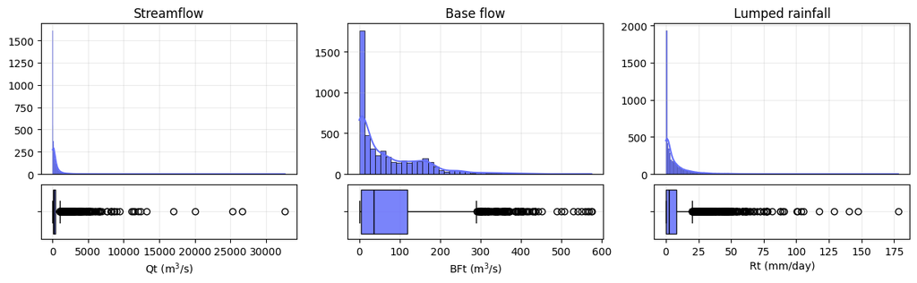

| Features | count | mean | std | min | 25% | 50% | 75% | 90% | 99% | max | kurt | skew | %zeros |
| --- | --- | --- | --- | --- | --- | --- | --- | --- | --- | --- | --- | --- | --- |
| Qt | 5002.0 | 419.786146 | 1158.384004 | 0.0 | 23.025 | 136.90 | 423.675 | 956.36 | 4411.917 | 32686.0 | 257.078632 | 12.820754 | 6.977209 |
| BFt | 5002.0 | 70.948481 | 84.803350 | 0.0 | 3.900 | 36.65 | 118.275 | 180.57 | 365.370 | 575.5 | 3.515674 | 1.664547 | 10.295882 |
| Rt | 5002.0 | 6.601799 | 11.626167 | 0.0 | 0.100 | 2.30 | 8.100 | 18.00 | 53.899 | 178.2 | 32.450727 | 4.381332 | 22.750900 |

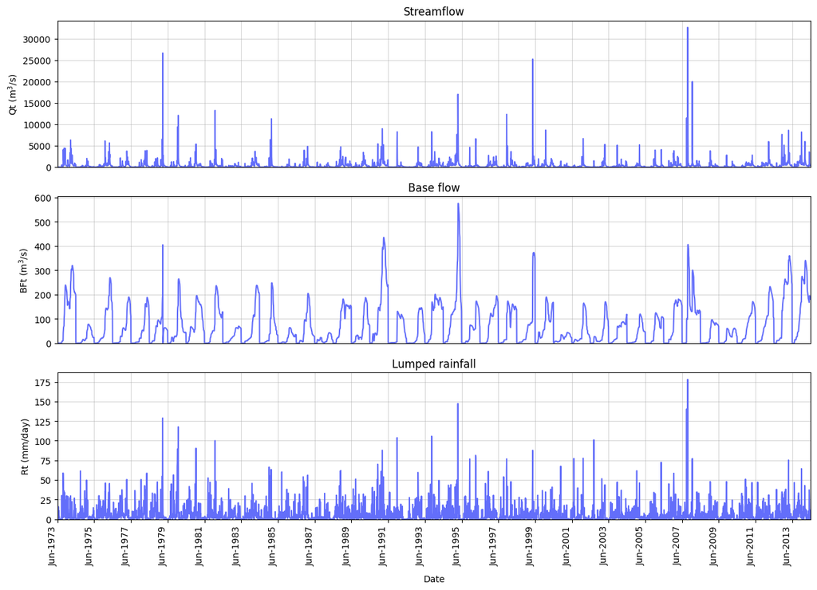

### 4.1.3 Correlation analysis

#### Autocorrelation

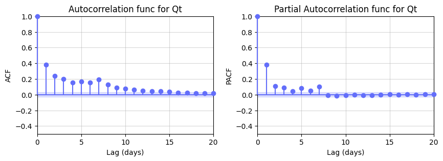

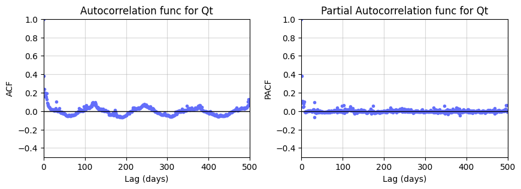

- The ACF decays quite rapidly to zero till 20 lags, however, is always positive.
- There is yearly seasonality in the data as expected (which occurs at every 122nd instance).
- The PACF becomes negative only after 7 lags, when it begins to oscillate randomly near zero.

#### Mutual information

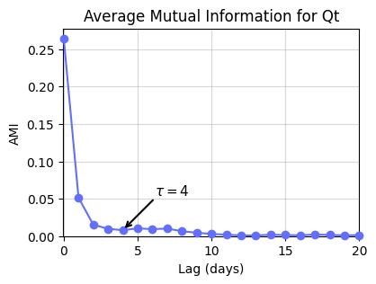

The AMI values decreases to its first minimum at $\tau$ = 4.

#### False Nearest Neighbour

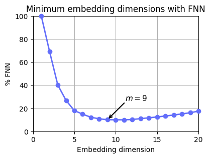

Using an optimal delay time of $\tau = 4$, the minimum embedding dimension is found out to be 9 for Burhanpur station, where the %FNN drops sharply from 100%, forms a plateau between $m = 9$ and $11$ with less than a 10% change, and then rises again.

#### Cross-correlation

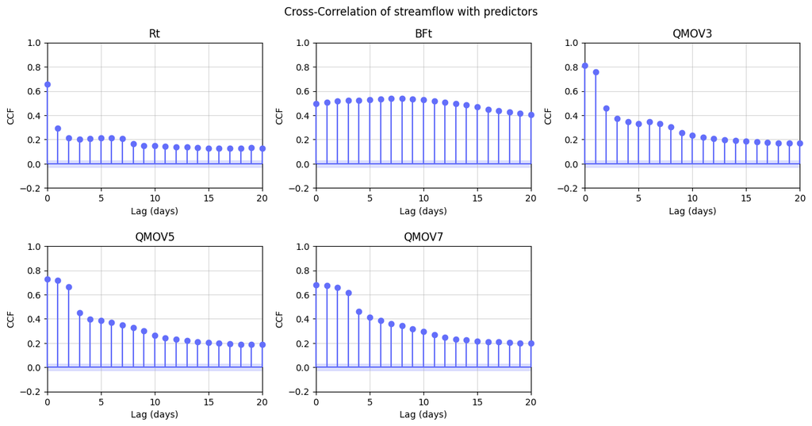

## **4.2 Modeling**

```python
BFI_max_bur = 0.29 # Maximum base flow index - Burhanpur
a = 0.98 # optimal filter parameter value
bur_full = load_data('Burhanpur.csv')

# Preprocess
bur_full = add_base_flow(bur_full, BFI_max=BFI_max_bur, a=a)
bur_full = add_moving_averages(bur_full)
bur_full = add_lagged_variables(bur_full)
```

```python
# Data portions
data_portion_cfgs = {'M1': 0.61, 'M2': 0.71, 'M3': 0.80}

# Sub-model configurations
sub_model_cfgs_bur = {
    'A': ['Qt-1', 'Qt-2', 'Qt-3'],
    'B': ['Rt-1', 'Rt-2', 'Rt-3'],
    'C': ['Qt-1', 'Qt-2', 'Qt-3', 'Rt-1'],
    'D': ['Qt-1', 'Qt-2', 'Rt-1', 'Rt-2', 'QMOV3', 'QMOV5'],
    'E': ['Qt-1', 'Qt-2', 'Rt-1', 'Rt-2', 'BFt-1', 'BFt-2', 'QMOV3', 'QMOV5'],
    'F': ['Qt-1', 'Qt-2', 'Qt-3', 'Rt-1', 'Rt-2', 'BFt-1', 'BFt-2', 'QMOV3', 'QMOV5']
}

# Model tree variants
mt_variants = {
    'PS':    [],
    'PUS':   ['-U'],
    'UPS':   ['-N'],
    'UPUS':  ['-N', '-U']
}
```

### 4.2.1 M1 - 60:40 split

```python
bur_train, bur_test = split_time_series(bur_full, train_size=data_portion_cfgs['M1'])

y_train, y_test = bur_train['Qt'], bur_test['Qt']
```

```python
data_portion = list(data_portion_cfgs)[0]

for cfg_key, features in sub_model_cfgs_bur.items():
    for variant_key, variant_params in mt_variants.items():
        # Prepare data
        train_df = bur_train[features + ['Qt']]
        test_df = bur_test[features + ['Qt']]

        train_weka = pandas_to_weka_instances(train_df)
        test_weka = pandas_to_weka_instances(test_df)

        # Train M5P
        m5p = Classifier(classname="weka.classifiers.trees.M5P", options=variant_params)
        m5p.build_classifier(train_weka)

        # Predictions
        y_train_pred = pd.Series(index=y_train.index[:len(train_df)], name='Qt')
        for i, inst in enumerate(train_weka):
            y_train_pred.iloc[i] = m5p.classify_instance(inst)

        y_test_pred = pd.Series(index=y_test.index[:len(test_df)], name='Qt')
        for i, inst in enumerate(test_weka):
            y_test_pred.iloc[i] = m5p.classify_instance(inst)

        # Number of rules
        scores_bur.loc[(data_portion, cfg_key, variant_key), 'Number of rules'] = int(str(m5p).split('Number of Rules : ')[1])

        # Calculate and store scores
        for metric_name, metric_func in metrics.items():
            tra_score = metric_func(y_train[:len(train_df)], y_train_pred)
            test_score = metric_func(y_test[:len(test_df)], y_test_pred)

            if metric_name != 'MARE':
                scores_bur.loc[(data_portion, cfg_key, variant_key), ('Train', metric_name)] = tra_score
            scores_bur.loc[(data_portion, cfg_key, variant_key), ('Test',  metric_name)] = test_score
```

### 4.2.2 M2 - 70:30 split

```python
bur_train, bur_test = split_time_series(bur_full, train_size=data_portion_cfgs['M2'])

y_train, y_test = bur_train['Qt'], bur_test['Qt']
```

```python
data_portion = list(data_portion_cfgs)[1]

for cfg_key, features in sub_model_cfgs_bur.items():
    for variant_key, variant_params in mt_variants.items():
        # Prepare data
        train_df = bur_train[features + ['Qt']]
        test_df = bur_test[features + ['Qt']]

        train_weka = pandas_to_weka_instances(train_df)
        test_weka = pandas_to_weka_instances(test_df)

        # Train M5P
        m5p = Classifier(classname="weka.classifiers.trees.M5P", options=variant_params)
        m5p.build_classifier(train_weka)

        # Predictions
        y_train_pred = pd.Series(index=y_train.index[:len(train_df)], name='Qt')
        for i, inst in enumerate(train_weka):
            y_train_pred.iloc[i] = m5p.classify_instance(inst)

        y_test_pred = pd.Series(index=y_test.index[:len(test_df)], name='Qt')
        for i, inst in enumerate(test_weka):
            y_test_pred.iloc[i] = m5p.classify_instance(inst)

        # Number of rules
        scores_bur.loc[(data_portion, cfg_key, variant_key), 'Number of rules'] = int(str(m5p).split('Number of Rules : ')[1])

        # Calculate and store scores
        for metric_name, metric_func in metrics.items():
            tra_score = metric_func(y_train[:len(train_df)], y_train_pred)
            test_score = metric_func(y_test[:len(test_df)], y_test_pred)

            if metric_name != 'MARE':
                scores_bur.loc[(data_portion, cfg_key, variant_key), ('Train', metric_name)] = tra_score
            scores_bur.loc[(data_portion, cfg_key, variant_key), ('Test',  metric_name)] = test_score
```

### 4.2.3 M3 - 80:20 split

```python
bur_train, bur_test = split_time_series(bur_full, train_size=data_portion_cfgs['M3'])

y_train, y_test = bur_train['Qt'], bur_test['Qt']
```

```python
data_portion = list(data_portion_cfgs)[2]

for cfg_key, features in sub_model_cfgs_bur.items():
    for variant_key, variant_params in mt_variants.items():
        # Prepare data
        train_df = bur_train[features + ['Qt']]
        test_df = bur_test[features + ['Qt']]

        train_weka = pandas_to_weka_instances(train_df)
        test_weka = pandas_to_weka_instances(test_df)

        # Train M5P
        m5p = Classifier(classname="weka.classifiers.trees.M5P", options=variant_params)
        m5p.build_classifier(train_weka)

        # Predictions
        y_train_pred = pd.Series(index=y_train.index[:len(train_df)], name='Qt')
        for i, inst in enumerate(train_weka):
            y_train_pred.iloc[i] = m5p.classify_instance(inst)

        y_test_pred = pd.Series(index=y_test.index[:len(test_df)], name='Qt')
        for i, inst in enumerate(test_weka):
            y_test_pred.iloc[i] = m5p.classify_instance(inst)

        # Number of rules
        scores_bur.loc[(data_portion, cfg_key, variant_key), 'Number of rules'] = int(str(m5p).split('Number of Rules : ')[1])

        # Calculate and store scores
        for metric_name, metric_func in metrics.items():
            tra_score = metric_func(y_train[:len(train_df)], y_train_pred)
            test_score = metric_func(y_test[:len(test_df)], y_test_pred)

            if metric_name != 'MARE':
                scores_bur.loc[(data_portion, cfg_key, variant_key), ('Train', metric_name)] = tra_score
            scores_bur.loc[(data_portion, cfg_key, variant_key), ('Test',  metric_name)] = test_score
```

### 4.2.4 Performance evaluation

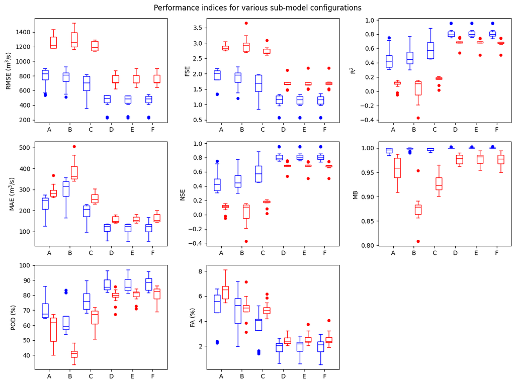

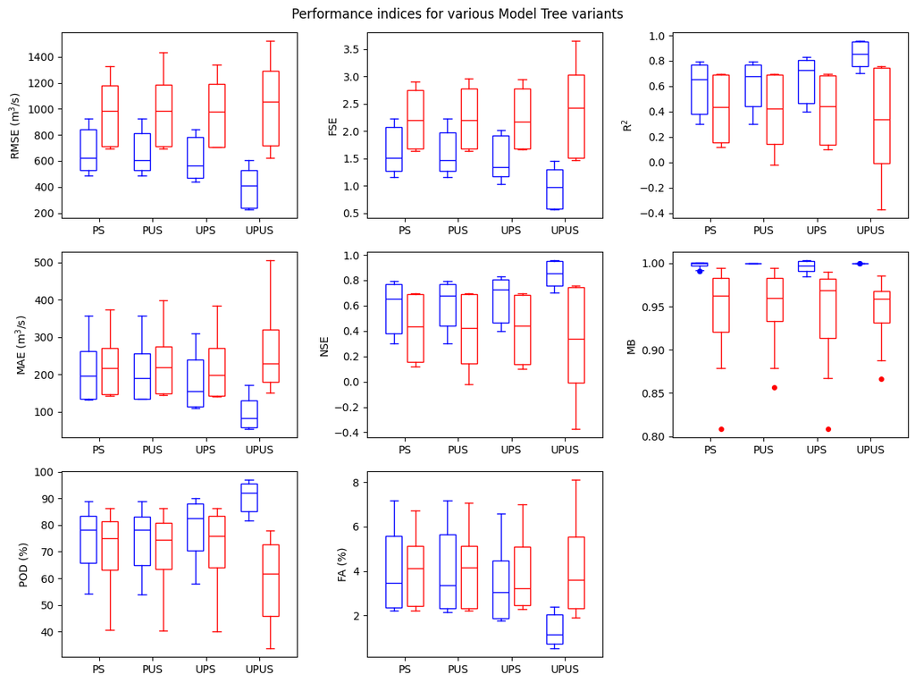

- Unpruned, unsmoothed models show better training performance; however, they overfit more compared to other model tree variants, while all variants have comparable performance during validation.
- Unpruned models show better prediction accuracy for peak flow instances as compared to the pruned models during training, as seen from Probability of Detection (POD).
- Although unpruned models show an edge over pruned models, they can sometimes lead to overfitting.

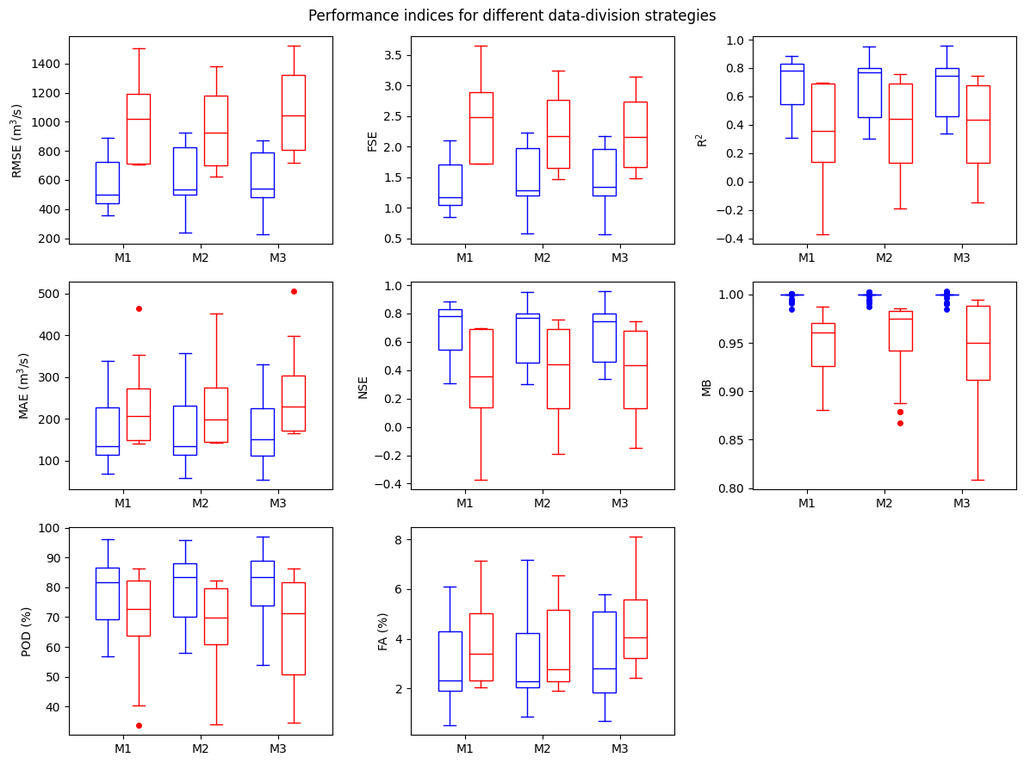

- The differences in model performance across the three data partitioning schemes — M1 (60:40), M2 (70:30), and M3 (80:20) — are minimal, indicating that the effect of data partitioning on model accuracy is largely insignificant.

### 4.2.5 Best-fit model selection

```python
# Level 1 screening
cond_r2  = (scores_bur[('Train', 'R2')]  >= 0.725) & (scores_bur[('Test', 'R2')]  >= 0.725)
cond_nse = (scores_bur[('Train', 'NSE')] >= 0.70)  & (scores_bur[('Test', 'NSE')] >= 0.70)
cond_rsr = (scores_bur[('Train', 'RSR')] <= 0.60)  & (scores_bur[('Test', 'RSR')] <= 0.60)
cond_mmr = (scores_bur[('Train', 'MMR')] <= 0.60)  & (scores_bur[('Test', 'MMR')] <= 0.60)
cond_mt_variant = scores_bur.index.get_level_values('MT variant').isin(['UPS', 'UPUS'])

level_1_cond = cond_r2 & cond_nse & cond_rsr & cond_mmr

level_1_passed_models = scores_bur[level_1_cond].copy()
conditional_round(level_1_passed_models)
```

| Data portioning | Sub-model cfg | Split Metric MT variant | Number of rules | Train RMSE | Train FSE | Train R2 | Train MAE | Train NSE | Train MB | Train POD | Train FA | Train RSR | Train MMR | Test RMSE | Test FSE | Test R2 | Test MAE | Test NSE | Test MB | Test POD | Test FA | Test RSR | Test MMR | Test MARE |
| --- | --- | --- | --- | --- | --- | --- | --- | --- | --- | --- | --- | --- | --- | --- | --- | --- | --- | --- | --- | --- | --- | --- | --- | --- |
| M2 | D | UPUS | 370.0 | 240.6 | 0.58 | 0.95 | 57.8 | 0.95 | 1.0 | 95.8 | 0.9 | 0.22 | 0.14 | 623.0 | 1.46 | 0.76 | 151.3 | 0.76 | 0.97 | 72.1 | 2.1 | 0.49 | 0.36 | 0.31 |
|  | E | UPUS | 362.0 | 242.0 | 0.58 | 0.95 | 58.2 | 0.95 | 1.0 | 94.4 | 0.9 | 0.22 | 0.14 | 639.8 | 1.50 | 0.74 | 156.6 | 0.74 | 0.98 | 72.8 | 2.1 | 0.51 | 0.37 | 0.31 |
|  | F | UPUS | 360.0 | 240.8 | 0.58 | 0.95 | 57.3 | 0.95 | 1.0 | 94.9 | 0.9 | 0.22 | 0.14 | 640.2 | 1.50 | 0.74 | 157.0 | 0.74 | 0.99 | 73.5 | 1.9 | 0.51 | 0.37 | 0.31 |
| M3 | D | UPUS | 385.0 | 227.1 | 0.57 | 0.96 | 54.8 | 0.96 | 1.0 | 96.4 | 0.8 | 0.21 | 0.14 | 716.0 | 1.48 | 0.75 | 179.3 | 0.75 | 0.96 | 67.3 | 2.5 | 0.50 | 0.37 | 0.32 |
|  | E | UPUS | 392.0 | 225.1 | 0.56 | 0.96 | 53.0 | 0.96 | 1.0 | 96.9 | 0.7 | 0.21 | 0.13 | 724.1 | 1.50 | 0.74 | 181.3 | 0.74 | 0.96 | 70.9 | 2.4 | 0.51 | 0.37 | 0.32 |
|  | F | UPUS | 384.0 | 224.6 | 0.56 | 0.96 | 52.9 | 0.96 | 1.0 | 95.9 | 0.7 | 0.21 | 0.13 | 719.0 | 1.49 | 0.74 | 180.8 | 0.74 | 0.96 | 69.1 | 2.5 | 0.51 | 0.37 | 0.31 |

```python
# Level 2 screening
pod = level_1_passed_models[('Test', 'POD')]
fa  = level_1_passed_models[('Test', 'FA')]

level_2_score = pod * (1 - fa)

level_2_cond = level_2_score >= 0.70

level_2_passed_models = level_1_passed_models[level_2_cond].copy()
conditional_round(level_2_passed_models)
```

| Data portioning | Sub-model cfg | Split Metric MT variant | Number of rules | Train RMSE | Train FSE | Train R2 | Train MAE | Train NSE | Train MB | Train POD | Train FA | Train RSR | Train MMR | Test RMSE | Test FSE | Test R2 | Test MAE | Test NSE | Test MB | Test POD | Test FA | Test RSR | Test MMR | Test MARE |
| --- | --- | --- | --- | --- | --- | --- | --- | --- | --- | --- | --- | --- | --- | --- | --- | --- | --- | --- | --- | --- | --- | --- | --- | --- |
| M2 | D | UPUS | 370.0 | 240.6 | 0.58 | 0.95 | 57.8 | 0.95 | 1.0 | 95.8 | 0.9 | 0.22 | 0.14 | 623.0 | 1.46 | 0.76 | 151.3 | 0.76 | 0.97 | 72.1 | 2.1 | 0.49 | 0.36 | 0.31 |
|  | E | UPUS | 362.0 | 242.0 | 0.58 | 0.95 | 58.2 | 0.95 | 1.0 | 94.4 | 0.9 | 0.22 | 0.14 | 639.8 | 1.50 | 0.74 | 156.6 | 0.74 | 0.98 | 72.8 | 2.1 | 0.51 | 0.37 | 0.31 |
|  | F | UPUS | 360.0 | 240.8 | 0.58 | 0.95 | 57.3 | 0.95 | 1.0 | 94.9 | 0.9 | 0.22 | 0.14 | 640.2 | 1.50 | 0.74 | 157.0 | 0.74 | 0.99 | 73.5 | 1.9 | 0.51 | 0.37 | 0.31 |

```python
# Level 3 screening
level_3_cond = level_2_passed_models[('Test', 'MARE')] <= 0.35

level_3_passed_models = level_2_passed_models[level_3_cond].copy()
conditional_round(level_3_passed_models)
```

| Data portioning | Sub-model cfg | Split Metric MT variant | Number of rules | Train RMSE | Train FSE | Train R2 | Train MAE | Train NSE | Train MB | Train POD | Train FA | Train RSR | Train MMR | Test RMSE | Test FSE | Test R2 | Test MAE | Test NSE | Test MB | Test POD | Test FA | Test RSR | Test MMR | Test MARE |
| --- | --- | --- | --- | --- | --- | --- | --- | --- | --- | --- | --- | --- | --- | --- | --- | --- | --- | --- | --- | --- | --- | --- | --- | --- |
| M2 | D | UPUS | 370.0 | 240.6 | 0.58 | 0.95 | 57.8 | 0.95 | 1.0 | 95.8 | 0.9 | 0.22 | 0.14 | 623.0 | 1.46 | 0.76 | 151.3 | 0.76 | 0.97 | 72.1 | 2.1 | 0.49 | 0.36 | 0.31 |
|  | E | UPUS | 362.0 | 242.0 | 0.58 | 0.95 | 58.2 | 0.95 | 1.0 | 94.4 | 0.9 | 0.22 | 0.14 | 639.8 | 1.50 | 0.74 | 156.6 | 0.74 | 0.98 | 72.8 | 2.1 | 0.51 | 0.37 | 0.31 |
|  | F | UPUS | 360.0 | 240.8 | 0.58 | 0.95 | 57.3 | 0.95 | 1.0 | 94.9 | 0.9 | 0.22 | 0.14 | 640.2 | 1.50 | 0.74 | 157.0 | 0.74 | 0.99 | 73.5 | 1.9 | 0.51 | 0.37 | 0.31 |

```python
# Level 4 screening
metrics_positive = ['R2', 'NSE', 'POD']       # Higher is better
metrics_negative = ['RSR', 'MMR', 'MARE']     # Lower is better

# Compute normalized metrics and performance score
norm = pd.DataFrame({
    metric: level_3_passed_models[('Test', metric)] for metric in metrics_positive
} | {
    metric: 1 - level_3_passed_models[('Test', metric)] for metric in metrics_negative
})

level_3_passed_models[('Test', 'PS')] = norm.sum(axis=1)
level_3_passed_models.sort_values(by=('Test', 'PS'), ascending=False, inplace=True)
conditional_round(level_3_passed_models)
```

| Data portioning | Sub-model cfg | Split Metric MT variant | Number of rules | Train RMSE | Train FSE | Train R2 | Train MAE | Train NSE | Train MB | Train POD | Train FA | Train RSR | Train MMR | Test RMSE | Test FSE | Test R2 | Test MAE | Test NSE | Test MB | Test POD | Test FA | Test RSR | Test MMR | Test MARE | Test PS |
| --- | --- | --- | --- | --- | --- | --- | --- | --- | --- | --- | --- | --- | --- | --- | --- | --- | --- | --- | --- | --- | --- | --- | --- | --- | --- |
| M2 | D | UPUS | 370.0 | 240.6 | 0.58 | 0.95 | 57.8 | 0.95 | 1.0 | 95.8 | 0.9 | 0.22 | 0.14 | 623.0 | 1.46 | 0.76 | 151.3 | 0.76 | 0.97 | 72.1 | 2.1 | 0.49 | 0.36 | 0.31 | 4.08 |
|  | E | UPUS | 362.0 | 242.0 | 0.58 | 0.95 | 58.2 | 0.95 | 1.0 | 94.4 | 0.9 | 0.22 | 0.14 | 639.8 | 1.50 | 0.74 | 156.6 | 0.74 | 0.98 | 72.8 | 2.1 | 0.51 | 0.37 | 0.31 | 4.04 |
|  | F | UPUS | 360.0 | 240.8 | 0.58 | 0.95 | 57.3 | 0.95 | 1.0 | 94.9 | 0.9 | 0.22 | 0.14 | 640.2 | 1.50 | 0.74 | 157.0 | 0.74 | 0.99 | 73.5 | 1.9 | 0.51 | 0.37 | 0.31 | 4.03 |

Thus, the best-fit model for Burhanpur station is found out as:  
The Unpruned-Unsmoothed M5P model trained on M2 (70:30) split, with 6 features `'Qt-1', 'Qt-2', 'Rt-1', 'Rt-2', 'QMOV3', 'QMOV5'`.

### 4.2.6 Final Model - Burhanpur

```python
# M2D UPUS
bur_train, bur_test = split_time_series(bur_full, train_size=0.71)
y_train, y_test = bur_train['Qt'], bur_test['Qt']

train_df = bur_train[['Qt-1', 'Qt-2', 'Rt-1', 'Rt-2', 'QMOV3', 'QMOV5', 'Qt']]
test_df = bur_test[['Qt-1', 'Qt-2', 'Rt-1', 'Rt-2', 'QMOV3', 'QMOV5', 'Qt']]

train_weka = pandas_to_weka_instances(train_df)
test_weka = pandas_to_weka_instances(test_df)

# Train M5P
m5p = Classifier(classname="weka.classifiers.trees.M5P", options=['-N', '-U'])
m5p.build_classifier(train_weka)

# Predictions
y_train_pred = pd.Series(index=y_train.index[:len(train_df)], name='Qt')
for i, inst in enumerate(train_weka):
    y_train_pred.iloc[i] = m5p.classify_instance(inst)

y_test_pred = pd.Series(index=y_test.index[:len(test_df)], name='Qt')
for i, inst in enumerate(test_weka):
    y_test_pred.iloc[i] = m5p.classify_instance(inst)
```

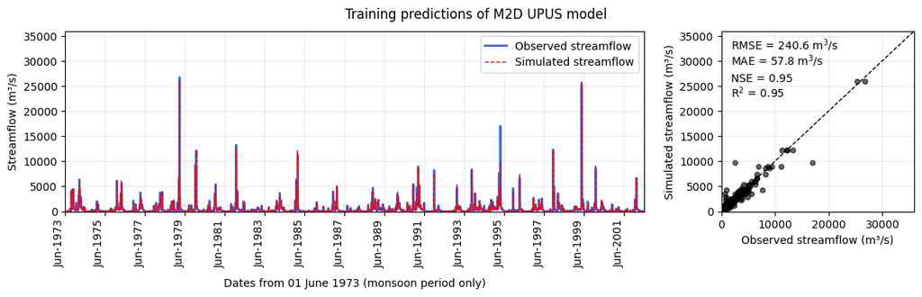

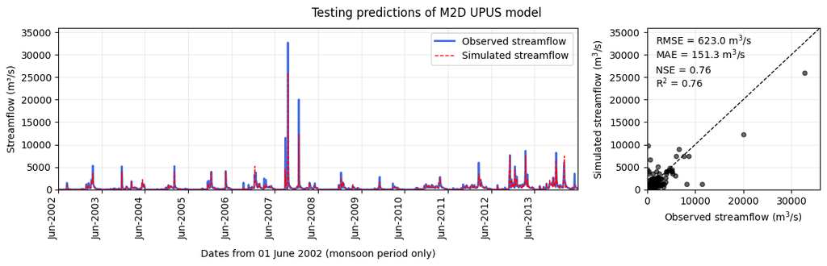

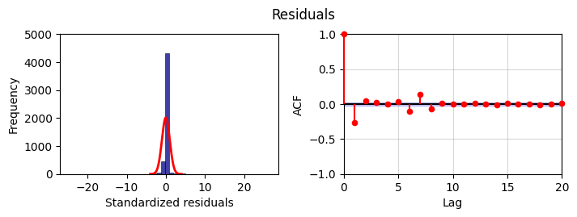

# **5. Station 2: Yerli**

## **5.1 EDA**

```python
yer_full.head()
```

|  | Date | Rt | Qt |
| --- | --- | --- | --- |
| 0 | 1973-06-01 | 0.0 | 0.2 |
| 1 | 1973-06-02 | 0.0 | 0.2 |
| 2 | 1973-06-03 | 0.0 | 0.2 |
| 3 | 1973-06-04 | 0.9 | 0.2 |
| 4 | 1973-06-05 | 8.9 | 0.2 |

```python
yer_full.info()
```

```
<class 'pandas.core.frame.DataFrame'>
RangeIndex: 5002 entries, 0 to 5001
Data columns (total 3 columns):
 #   Column  Non-Null Count  Dtype
---  ------  --------------  -----
 0   Date    5002 non-null   datetime64[ns]
 1   Rt      5002 non-null   float64
 2   Qt      5002 non-null   float64
dtypes: datetime64[ns](1), float64(2)
memory usage: 117.4 KB
```

```python
# Number of Years with months/days
yer_full.groupby([yer_full['Date'].dt.month.rename('Month'),yer_full['Date'].dt.day])['Date'].apply(lambda x: x.dt.year.nunique())
```

```
Month  Date
6      1       41
       2       41
       3       41
       4       41
       5       41
               ..
9      27      41
       28      41
       29      41
       30      40
10     1        1
Name: Date, Length: 123, dtype: int64
```

- The months of June, July, August, and September appear in all the years in the data. All the days of months appear in all the years, except for 2012 and 2013.
- October is present only once, in the year 2013 with a single instance, and in 2012, 30th September is not present.

```python
yer_full['Date'].dt.year.value_counts().value_counts()
```

```
count
122    39
123     1
121     1
Name: count, dtype: int64
```

- The data is evenly distributed, and there are almost equal number of instances (122) per year, except for years 2012 & 2013.
- We'll consider the entire dataset from 1973-2013 for exploration.

```python
# Exploration set
data_eda = yer_full.copy()
```

### 5.1.1 Feature Engineering

#### Base flow

```python
a = 0.98
BFI_max = 0.29

for year, group in data_eda.groupby(data_eda['Date'].dt.year):
    Qt = group['Qt']
    bft = [0]

    for k in range(1, len(Qt)):
        yk = Qt.iloc[k]
        bk_1 = bft[k-1]
        bk = ((1 - BFI_max) * a * bk_1 + (1 - a) * BFI_max * yk) / (1 - a * BFI_max)
        bft.append(min(yk, bk))

    data_eda.loc[Qt.index, 'BFt'] = bft

data_eda['BFt'] = data_eda['BFt'].round(1)
```

#### Moving averages

```python
for n in [3, 5, 7]:
    data_eda[f'QMOV{n}'] = data_eda\
        .groupby(data_eda['Date'].dt.year)['Qt']\
        .apply(lambda x: x.shift(-n//2+1).rolling(n).mean()).values.round(1)

data_eda.bfill(inplace=True)
data_eda.ffill(inplace=True)
```

#### Lagged variables

```python
for att in ['Qt', 'Rt', 'BFt']:
    for i in range(1, 3+1):
        data_eda[f"{att}-{i}"] = data_eda.groupby(data_eda['Date'].dt.year)[att].apply(lambda x: x.shift(i)).bfill().values
```

### 5.1.2 Summary statistics

```python
num_att = ['Qt', 'BFt', 'Rt']
var_names = ['Streamflow', 'Base flow', 'Lumped rainfall']
```

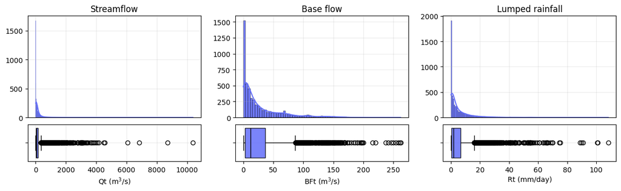

| Features | count | mean | std | min | 25% | 50% | 75% | 90% | 99% | max | kurt | skew | %zeros |
| --- | --- | --- | --- | --- | --- | --- | --- | --- | --- | --- | --- | --- | --- |
| Qt | 5002.0 | 173.588808 | 458.574023 | 0.0 | 8.4 | 42.70 | 145.625 | 388.34 | 2286.820 | 10380.0 | 106.403359 | 8.018534 | 9.376250 |
| BFt | 5002.0 | 26.807437 | 36.249169 | 0.0 | 2.4 | 11.75 | 36.100 | 74.89 | 156.098 | 262.0 | 5.388695 | 2.141112 | 12.195122 |
| Rt | 5002.0 | 5.312975 | 9.331433 | 0.0 | 0.2 | 1.70 | 6.500 | 14.70 | 47.098 | 108.3 | 21.986157 | 3.875958 | 19.712115 |

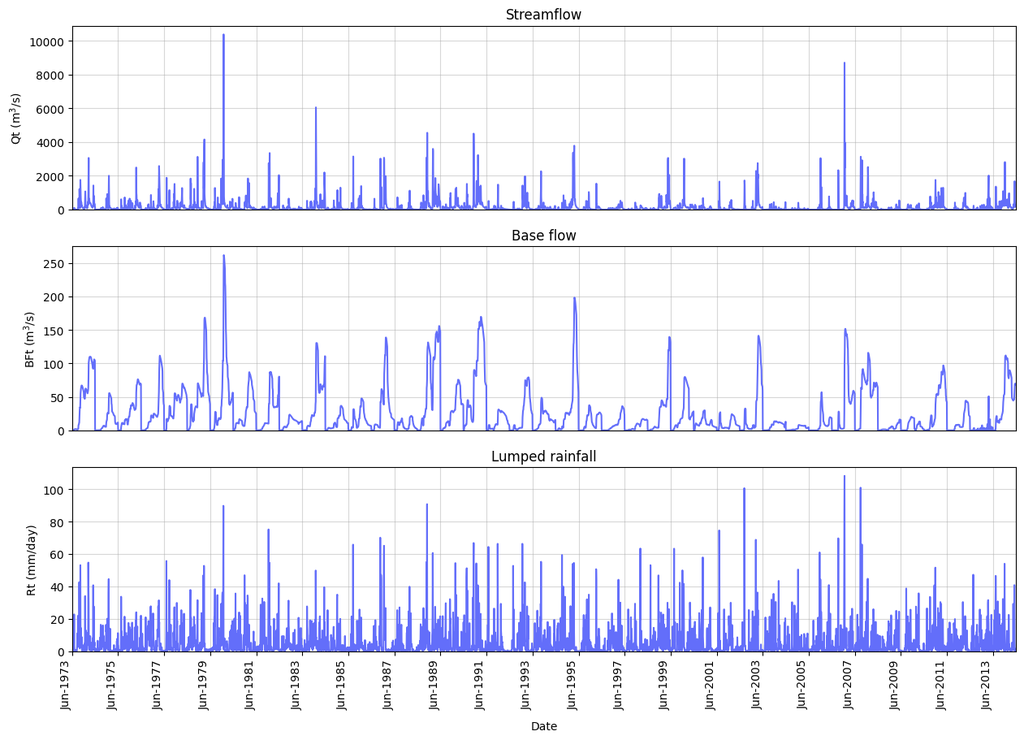

### 5.1.3 Correlation analysis

#### Autocorrelation

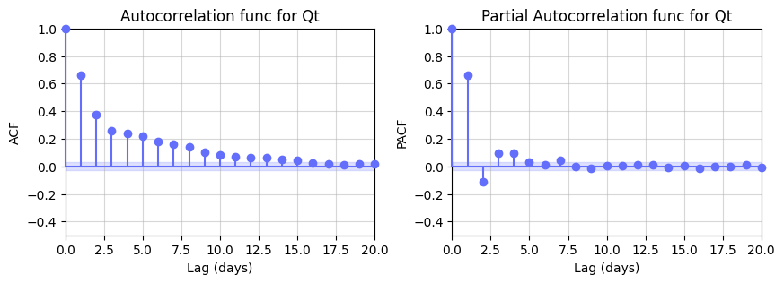

#### Mutual information

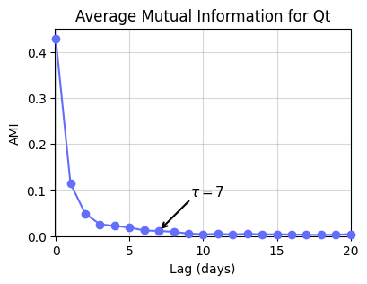

The AMI values decrease and reach a plateau around $\tau$ = 7, with less than 10% variation.

#### False Nearest Neighbour

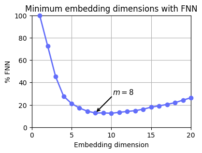

Using an optimal delay time of $\tau = 7$, the minimum embedding dimension is found out to be 8 for Yerli station.

#### Cross-correlation

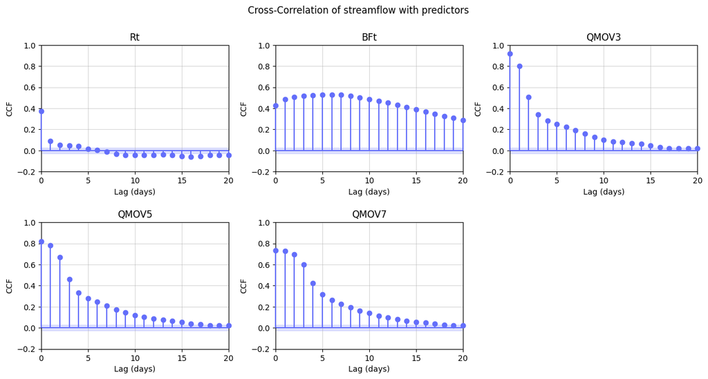

## **5.2 Modeling**

```python
BFI_max_yer = 0.50 # Maximum base flow index - Yerli
a = 0.98 # optimal filter parameter value
yer_full = load_data('Yerli.csv')

# Preprocess
yer_full = add_base_flow(yer_full, BFI_max=BFI_max_yer, a=a)
yer_full = add_moving_averages(yer_full)
yer_full = add_lagged_variables(yer_full)
```

```python
# Data portions - train size
data_portion_cfgs = {'M1': 0.61, 'M2': 0.71, 'M3': 0.80}

# Model configurations
sub_model_cfgs_yer = {
    'A': ['Qt-1', 'Qt-2', 'Qt-3'],
    'B': ['Rt-1', 'Rt-2', 'Rt-3'],
    'C': ['Qt-1', 'Qt-2', 'Rt-1', 'Rt-2'],
    'D': ['Qt-1', 'Qt-2', 'Rt-1', 'Rt-2', 'BFt-1', 'BFt-2'],
    'E': ['Qt-1', 'Qt-2', 'Rt-1', 'BFt-1', 'BFt-2', 'QMOV3', 'QMOV5'],
    'F': ['Qt-1', 'Qt-2', 'Rt-1', 'BFt-1', 'BFt-2', 'QMOV3', 'QMOV5', 'QMOV7']
}

# Model tree variants
mt_variants = {
    'PS':    [],
    'PUS':   ['-U'],
    'UPS':   ['-N'],
    'UPUS':  ['-N', '-U']
}
```

### 5.2.1 M1 - 60:40 split

```python
yer_train, yer_test = split_time_series(yer_full, train_size=data_portion_cfgs['M1'])

y_train, y_test = yer_train['Qt'], yer_test['Qt']
```

```python
data_portion = list(data_portion_cfgs)[0]

for cfg_key, features in sub_model_cfgs_yer.items():
    for variant_key, variant_params in mt_variants.items():
        # Prepare data
        train_df = yer_train[features + ['Qt']]
        test_df = yer_test[features + ['Qt']]

        train_weka = pandas_to_weka_instances(train_df)
        test_weka = pandas_to_weka_instances(test_df)

        # Train M5P
        m5p = Classifier(classname="weka.classifiers.trees.M5P", options=variant_params)
        m5p.build_classifier(train_weka)

        # Predictions
        y_train_pred = pd.Series(index=y_train.index[:len(train_df)], name='Qt')
        for i, inst in enumerate(train_weka):
            y_train_pred.iloc[i] = m5p.classify_instance(inst)

        y_test_pred = pd.Series(index=y_test.index[:len(test_df)], name='Qt')
        for i, inst in enumerate(test_weka):
            y_test_pred.iloc[i] = m5p.classify_instance(inst)

        # Number of rules
        scores_yer.loc[(data_portion, cfg_key, variant_key), 'Number of rules'] = int(str(m5p).split('Number of Rules : ')[1])

        # Calculate and store scores
        for metric_name, metric_func in metrics.items():
            tra_score = metric_func(y_train[:len(train_df)], y_train_pred)
            test_score = metric_func(y_test[:len(test_df)], y_test_pred)

            if metric_name != 'MARE':
                scores_yer.loc[(data_portion, cfg_key, variant_key), ('Train', metric_name)] = tra_score
            scores_yer.loc[(data_portion, cfg_key, variant_key), ('Test',  metric_name)] = test_score
```

### 5.2.2 M2 - 70:30 split

```python
yer_train, yer_test = split_time_series(yer_full, train_size=data_portion_cfgs['M2'])

y_train, y_test = yer_train['Qt'], yer_test['Qt']
```

```python
data_portion = list(data_portion_cfgs)[1]

for cfg_key, features in sub_model_cfgs_yer.items():
    for variant_key, variant_params in mt_variants.items():
        # Prepare data
        train_df = yer_train[features + ['Qt']]
        test_df = yer_test[features + ['Qt']]

        train_weka = pandas_to_weka_instances(train_df)
        test_weka = pandas_to_weka_instances(test_df)

        # Train M5P
        m5p = Classifier(classname="weka.classifiers.trees.M5P", options=variant_params)
        m5p.build_classifier(train_weka)

        # Predictions
        y_train_pred = pd.Series(index=y_train.index[:len(train_df)], name='Qt')
        for i, inst in enumerate(train_weka):
            y_train_pred.iloc[i] = m5p.classify_instance(inst)

        y_test_pred = pd.Series(index=y_test.index[:len(test_df)], name='Qt')
        for i, inst in enumerate(test_weka):
            y_test_pred.iloc[i] = m5p.classify_instance(inst)

        # Number of rules
        scores_yer.loc[(data_portion, cfg_key, variant_key), 'Number of rules'] = int(str(m5p).split('Number of Rules : ')[1])

        # Calculate and store scores
        for metric_name, metric_func in metrics.items():
            tra_score = metric_func(y_train[:len(train_df)], y_train_pred)
            test_score = metric_func(y_test[:len(test_df)], y_test_pred)

            if metric_name != 'MARE':
                scores_yer.loc[(data_portion, cfg_key, variant_key), ('Train', metric_name)] = tra_score
            scores_yer.loc[(data_portion, cfg_key, variant_key), ('Test',  metric_name)] = test_score
```

### 5.2.3 M3 - 80:20 split

```python
yer_train, yer_test = split_time_series(yer_full, train_size=data_portion_cfgs['M3'])

y_train, y_test = yer_train['Qt'], yer_test['Qt']
```

```python
data_portion = list(data_portion_cfgs)[2]

for cfg_key, features in sub_model_cfgs_yer.items():
    for variant_key, variant_params in mt_variants.items():
        # Prepare data
        train_df = yer_train[features + ['Qt']]
        test_df = yer_test[features + ['Qt']]

        train_weka = pandas_to_weka_instances(train_df)
        test_weka = pandas_to_weka_instances(test_df)

        # Train M5P
        m5p = Classifier(classname="weka.classifiers.trees.M5P", options=variant_params)
        m5p.build_classifier(train_weka)

        # Predictions
        y_train_pred = pd.Series(index=y_train.index[:len(train_df)], name='Qt')
        for i, inst in enumerate(train_weka):
            y_train_pred.iloc[i] = m5p.classify_instance(inst)

        y_test_pred = pd.Series(index=y_test.index[:len(test_df)], name='Qt')
        for i, inst in enumerate(test_weka):
            y_test_pred.iloc[i] = m5p.classify_instance(inst)

        # Number of rules
        scores_yer.loc[(data_portion, cfg_key, variant_key), 'Number of rules'] = int(str(m5p).split('Number of Rules : ')[1])

        # Calculate and store scores
        for metric_name, metric_func in metrics.items():
            tra_score = metric_func(y_train[:len(train_df)], y_train_pred)
            test_score = metric_func(y_test[:len(test_df)], y_test_pred)

            if metric_name != 'MARE':
                scores_yer.loc[(data_portion, cfg_key, variant_key), ('Train', metric_name)] = tra_score
            scores_yer.loc[(data_portion, cfg_key, variant_key), ('Test',  metric_name)] = test_score
```

### 5.2.4 Performance evaluation

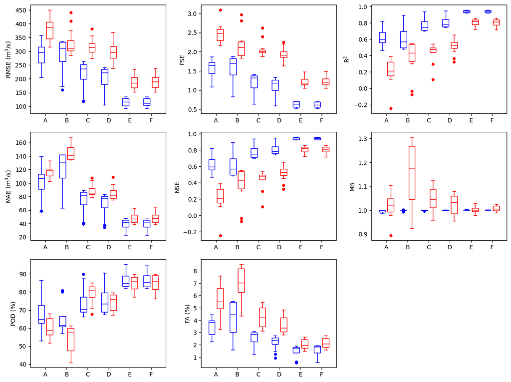

- The models 'A', 'B', 'C' and 'D' shows higher forecasting error and lower predictability compared to models 'E' and 'F'.
- The models 'A' and 'B' shows higher variability, models 'C' and 'D' shows moderate variability and models 'E' and 'F' show lower variability across all metrics.  
  Some 'A' and 'B' models also shows negative R² and NSE values.
- All models except 'E' and 'F' overestimated predicted values as indicated by Multiplicative Bias (MB). Therefore, sub-model combinations from models 'E' and 'F' should be considered to find the best-fit model for predicting streamflow at the Yerli station.

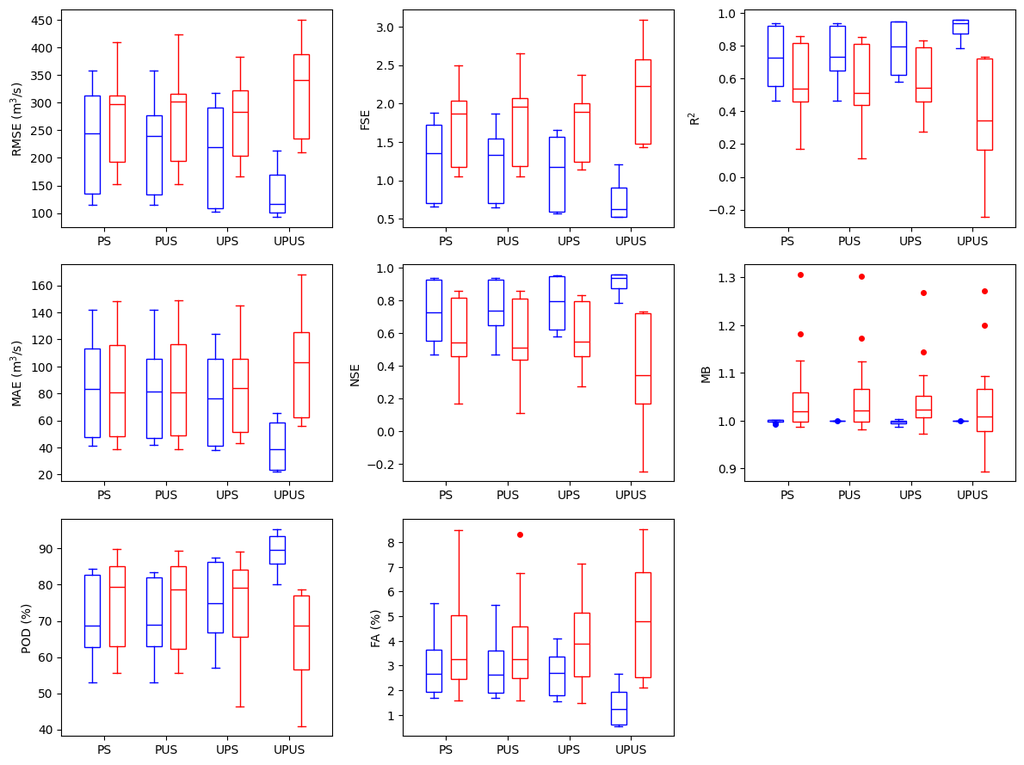

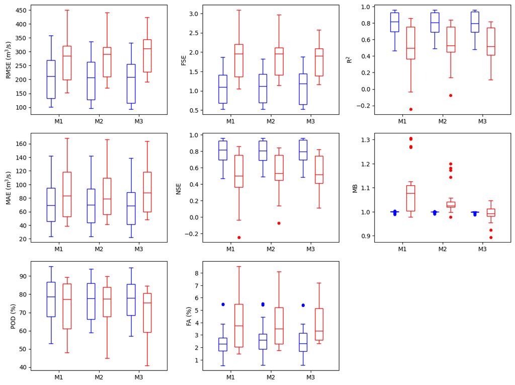

- The differences in model performance across the three data partitioning schemes — M1 (60:40), M2 (70:30), and M3 (80:20) — are minimal, indicating that the effect of data partitioning on model accuracy is largely insignificant.
- Higher variability observed in model performances across all metrics is possibly due to the high variance, skewness and high percentage of zero streamflow values in the dataset.
- Finally, Unpruned 'E' and 'F' models should be considered for best-fit model selection.

### 5.2.5 Best-fit model selection

```python
# Level 1 screening
cond_r2  = (scores_yer[('Train', 'R2')]  >= 0.725) & (scores_yer[('Test', 'R2')]  >= 0.725)
cond_nse = (scores_yer[('Train', 'NSE')] >= 0.70)  & (scores_yer[('Test', 'NSE')] >= 0.70)
cond_rsr = (scores_yer[('Train', 'RSR')] <= 0.60)  & (scores_yer[('Test', 'RSR')] <= 0.60)
cond_mmr = (scores_yer[('Train', 'MMR')] <= 0.60)  & (scores_yer[('Test', 'MMR')] <= 0.60)
cond_mt_variant = scores_bur.index.get_level_values('MT variant').isin(['UPS', 'UPUS'])

level_1_cond = cond_r2 & cond_nse & cond_rsr & cond_mmr & cond_mt_variant

level_1_passed_models = scores_yer[level_1_cond].copy()
conditional_round(level_1_passed_models)
```

| Data portioning | Sub-model cfg | Split Metric MT variant | Number of rules | Train RMSE | Train FSE | Train R2 | Train MAE | Train NSE | Train MB | Train POD | Train FA | Train RSR | Train MMR | Test RMSE | Test FSE | Test R2 | Test MAE | Test NSE | Test MB | Test POD | Test FA | Test RSR | Test MMR | Test MARE |
| --- | --- | --- | --- | --- | --- | --- | --- | --- | --- | --- | --- | --- | --- | --- | --- | --- | --- | --- | --- | --- | --- | --- | --- | --- |
| M1 | E | UPS | 346.0 | 109.2 | 0.57 | 0.95 | 41.3 | 0.95 | 1.0 | 86.9 | 1.6 | 0.22 | 0.22 | 165.8 | 1.14 | 0.83 | 43.0 | 0.83 | 1.01 | 87.2 | 1.5 | 0.41 | 0.30 | 0.34 |
|  | F | UPS | 342.0 | 109.3 | 0.57 | 0.95 | 41.2 | 0.95 | 1.0 | 87.6 | 1.7 | 0.22 | 0.22 | 166.9 | 1.15 | 0.83 | 43.6 | 0.83 | 1.01 | 87.2 | 1.8 | 0.41 | 0.30 | 0.34 |
|  |  | UPUS | 342.0 | 102.1 | 0.53 | 0.96 | 23.9 | 0.96 | 1.0 | 94.1 | 0.6 | 0.21 | 0.12 | 209.3 | 1.44 | 0.73 | 55.7 | 0.73 | 1.00 | 78.1 | 2.3 | 0.52 | 0.38 | 0.42 |
| M2 | E | UPS | 394.0 | 107.3 | 0.58 | 0.95 | 40.0 | 0.95 | 1.0 | 86.2 | 1.8 | 0.23 | 0.22 | 180.7 | 1.22 | 0.82 | 45.9 | 0.82 | 1.02 | 89.1 | 1.8 | 0.43 | 0.31 | 0.35 |
|  |  | UPUS | 394.0 | 97.2 | 0.53 | 0.96 | 23.5 | 0.96 | 1.0 | 92.9 | 0.6 | 0.21 | 0.13 | 219.7 | 1.48 | 0.73 | 58.8 | 0.73 | 1.02 | 77.6 | 2.6 | 0.52 | 0.40 | 0.45 |
|  | F | UPS | 387.0 | 108.3 | 0.59 | 0.95 | 40.2 | 0.95 | 1.0 | 86.4 | 1.8 | 0.23 | 0.22 | 181.2 | 1.22 | 0.82 | 46.1 | 0.82 | 1.02 | 88.4 | 1.8 | 0.43 | 0.31 | 0.36 |
|  |  | UPUS | 387.0 | 97.0 | 0.53 | 0.96 | 23.3 | 0.96 | 1.0 | 93.8 | 0.6 | 0.21 | 0.13 | 220.7 | 1.48 | 0.73 | 59.3 | 0.73 | 1.02 | 76.2 | 2.4 | 0.52 | 0.40 | 0.45 |
| M3 | E | UPS | 407.0 | 103.0 | 0.58 | 0.95 | 38.2 | 0.95 | 1.0 | 87.5 | 1.6 | 0.22 | 0.22 | 204.0 | 1.24 | 0.79 | 51.6 | 0.79 | 1.03 | 82.7 | 2.6 | 0.45 | 0.31 | 0.41 |
|  |  | UPUS | 407.0 | 93.4 | 0.53 | 0.96 | 22.5 | 0.96 | 1.0 | 93.6 | 0.6 | 0.20 | 0.13 | 234.8 | 1.43 | 0.73 | 62.1 | 0.73 | 1.00 | 77.3 | 2.3 | 0.52 | 0.38 | 0.45 |
|  | F | UPS | 406.0 | 103.8 | 0.59 | 0.95 | 38.3 | 0.95 | 1.0 | 87.2 | 1.6 | 0.23 | 0.22 | 204.6 | 1.25 | 0.79 | 51.9 | 0.79 | 1.03 | 82.7 | 2.5 | 0.46 | 0.32 | 0.41 |

```python
# Level 2 screening
pod = level_1_passed_models[('Test', 'POD')]
fa  = level_1_passed_models[('Test', 'FA')]

level_2_score = pod * (1 - fa)

level_2_cond = level_2_score >= 0.70

level_2_passed_models = level_1_passed_models[level_2_cond].copy()
conditional_round(level_2_passed_models)
```

| Data portioning | Sub-model cfg | Split Metric MT variant | Number of rules | Train RMSE | Train FSE | Train R2 | Train MAE | Train NSE | Train MB | Train POD | Train FA | Train RSR | Train MMR | Test RMSE | Test FSE | Test R2 | Test MAE | Test NSE | Test MB | Test POD | Test FA | Test RSR | Test MMR | Test MARE |
| --- | --- | --- | --- | --- | --- | --- | --- | --- | --- | --- | --- | --- | --- | --- | --- | --- | --- | --- | --- | --- | --- | --- | --- | --- |
| M1 | E | UPS | 346.0 | 109.2 | 0.57 | 0.95 | 41.3 | 0.95 | 1.0 | 86.9 | 1.6 | 0.22 | 0.22 | 165.8 | 1.14 | 0.83 | 43.0 | 0.83 | 1.01 | 87.2 | 1.5 | 0.41 | 0.30 | 0.34 |
|  | F | UPS | 342.0 | 109.3 | 0.57 | 0.95 | 41.2 | 0.95 | 1.0 | 87.6 | 1.7 | 0.22 | 0.22 | 166.9 | 1.15 | 0.83 | 43.6 | 0.83 | 1.01 | 87.2 | 1.8 | 0.41 | 0.30 | 0.34 |
|  |  | UPUS | 342.0 | 102.1 | 0.53 | 0.96 | 23.9 | 0.96 | 1.0 | 94.1 | 0.6 | 0.21 | 0.12 | 209.3 | 1.44 | 0.73 | 55.7 | 0.73 | 1.00 | 78.1 | 2.3 | 0.52 | 0.38 | 0.42 |
| M2 | E | UPS | 394.0 | 107.3 | 0.58 | 0.95 | 40.0 | 0.95 | 1.0 | 86.2 | 1.8 | 0.23 | 0.22 | 180.7 | 1.22 | 0.82 | 45.9 | 0.82 | 1.02 | 89.1 | 1.8 | 0.43 | 0.31 | 0.35 |
|  |  | UPUS | 394.0 | 97.2 | 0.53 | 0.96 | 23.5 | 0.96 | 1.0 | 92.9 | 0.6 | 0.21 | 0.13 | 219.7 | 1.48 | 0.73 | 58.8 | 0.73 | 1.02 | 77.6 | 2.6 | 0.52 | 0.40 | 0.45 |
|  | F | UPS | 387.0 | 108.3 | 0.59 | 0.95 | 40.2 | 0.95 | 1.0 | 86.4 | 1.8 | 0.23 | 0.22 | 181.2 | 1.22 | 0.82 | 46.1 | 0.82 | 1.02 | 88.4 | 1.8 | 0.43 | 0.31 | 0.36 |
|  |  | UPUS | 387.0 | 97.0 | 0.53 | 0.96 | 23.3 | 0.96 | 1.0 | 93.8 | 0.6 | 0.21 | 0.13 | 220.7 | 1.48 | 0.73 | 59.3 | 0.73 | 1.02 | 76.2 | 2.4 | 0.52 | 0.40 | 0.45 |
| M3 | E | UPS | 407.0 | 103.0 | 0.58 | 0.95 | 38.2 | 0.95 | 1.0 | 87.5 | 1.6 | 0.22 | 0.22 | 204.0 | 1.24 | 0.79 | 51.6 | 0.79 | 1.03 | 82.7 | 2.6 | 0.45 | 0.31 | 0.41 |
|  |  | UPUS | 407.0 | 93.4 | 0.53 | 0.96 | 22.5 | 0.96 | 1.0 | 93.6 | 0.6 | 0.20 | 0.13 | 234.8 | 1.43 | 0.73 | 62.1 | 0.73 | 1.00 | 77.3 | 2.3 | 0.52 | 0.38 | 0.45 |
|  | F | UPS | 406.0 | 103.8 | 0.59 | 0.95 | 38.3 | 0.95 | 1.0 | 87.2 | 1.6 | 0.23 | 0.22 | 204.6 | 1.25 | 0.79 | 51.9 | 0.79 | 1.03 | 82.7 | 2.5 | 0.46 | 0.32 | 0.41 |

```python
# Level 3 screening
level_3_cond = level_2_passed_models[('Test', 'MARE')] <= 0.35

level_3_passed_models = level_2_passed_models[level_3_cond].copy()
conditional_round(level_3_passed_models)
```

| Data portioning | Sub-model cfg | Split Metric MT variant | Number of rules | Train RMSE | Train FSE | Train R2 | Train MAE | Train NSE | Train MB | Train POD | Train FA | Train RSR | Train MMR | Test RMSE | Test FSE | Test R2 | Test MAE | Test NSE | Test MB | Test POD | Test FA | Test RSR | Test MMR | Test MARE |
| --- | --- | --- | --- | --- | --- | --- | --- | --- | --- | --- | --- | --- | --- | --- | --- | --- | --- | --- | --- | --- | --- | --- | --- | --- |
| M1 | E | UPS | 346.0 | 109.2 | 0.57 | 0.95 | 41.3 | 0.95 | 1.0 | 86.9 | 1.6 | 0.22 | 0.22 | 165.8 | 1.14 | 0.83 | 43.0 | 0.83 | 1.01 | 87.2 | 1.5 | 0.41 | 0.3 | 0.34 |
|  | F | UPS | 342.0 | 109.3 | 0.57 | 0.95 | 41.2 | 0.95 | 1.0 | 87.6 | 1.7 | 0.22 | 0.22 | 166.9 | 1.15 | 0.83 | 43.6 | 0.83 | 1.01 | 87.2 | 1.8 | 0.41 | 0.3 | 0.34 |

```python
# Level 4 screening
metrics_positive = ['R2', 'NSE', 'POD']       # Higher is better
metrics_negative = ['RSR', 'MMR', 'MARE']     # Lower is better

# Compute normalized metrics and performance score
norm = pd.DataFrame({
    metric: level_3_passed_models[('Test', metric)] for metric in metrics_positive
} | {
    metric: 1 - level_3_passed_models[('Test', metric)] for metric in metrics_negative
})

level_3_passed_models[('Test', 'PS')] = norm.sum(axis=1)
level_3_passed_models.sort_values(by=('Test', 'PS'), ascending=False, inplace=True)
conditional_round(level_3_passed_models)
```

| Data portioning | Sub-model cfg | Split Metric MT variant | Number of rules | Train RMSE | Train FSE | Train R2 | Train MAE | Train NSE | Train MB | Train POD | Train FA | Train RSR | Train MMR | Test RMSE | Test FSE | Test R2 | Test MAE | Test NSE | Test MB | Test POD | Test FA | Test RSR | Test MMR | Test MARE | Test PS |
| --- | --- | --- | --- | --- | --- | --- | --- | --- | --- | --- | --- | --- | --- | --- | --- | --- | --- | --- | --- | --- | --- | --- | --- | --- | --- |
| M1 | E | UPS | 346.0 | 109.2 | 0.57 | 0.95 | 41.3 | 0.95 | 1.0 | 86.9 | 1.6 | 0.22 | 0.22 | 165.8 | 1.14 | 0.83 | 43.0 | 0.83 | 1.01 | 87.2 | 1.5 | 0.41 | 0.3 | 0.34 | 4.48 |
|  | F | UPS | 342.0 | 109.3 | 0.57 | 0.95 | 41.2 | 0.95 | 1.0 | 87.6 | 1.7 | 0.22 | 0.22 | 166.9 | 1.15 | 0.83 | 43.6 | 0.83 | 1.01 | 87.2 | 1.8 | 0.41 | 0.3 | 0.34 | 4.47 |

### 5.2.6 Final Model - Yerli

```python
# M1E UPS
yer_train, yer_test = split_time_series(yer_full, train_size=0.61)
y_train, y_test = yer_train['Qt'], yer_test['Qt']

train_df = yer_train[['Qt-1', 'Qt-2', 'Rt-1', 'BFt-1', 'BFt-2', 'QMOV3', 'QMOV5', 'Qt']]
test_df = yer_test[['Qt-1', 'Qt-2', 'Rt-1', 'BFt-1', 'BFt-2', 'QMOV3', 'QMOV5', 'Qt']]

train_weka = pandas_to_weka_instances(train_df)
test_weka = pandas_to_weka_instances(test_df)

# Train M5P
m5p = Classifier(classname="weka.classifiers.trees.M5P", options=['-N'])
m5p.build_classifier(train_weka)

# Predictions
y_train_pred = pd.Series(index=y_train.index[:len(train_df)], name='Qt')
for i, inst in enumerate(train_weka):
    y_train_pred.iloc[i] = m5p.classify_instance(inst)

y_test_pred = pd.Series(index=y_test.index[:len(test_df)], name='Qt')
for i, inst in enumerate(test_weka):
    y_test_pred.iloc[i] = m5p.classify_instance(inst)
```

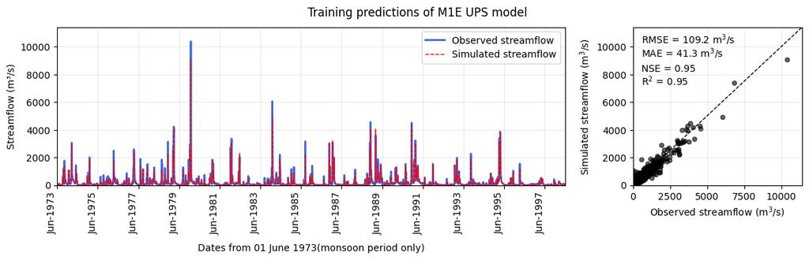

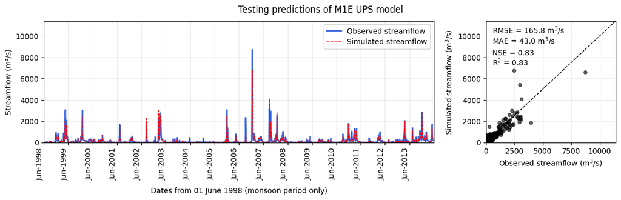

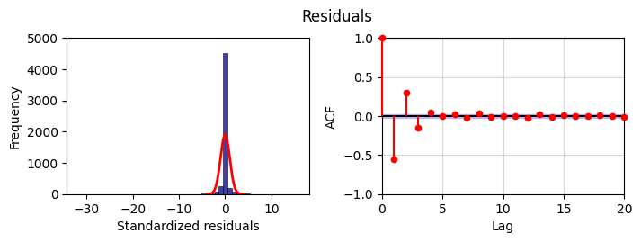

```python
jvm.stop()
print("Java Virtual Machine stopped.")
```

```
Java Virtual Machine stopped.
```

# **6. Conclusion**

The Model Tree approach was used to develop one-day ahead streamflow prediction models for two stations with varying physio-climatic conditions. Performance was evaluated based on input features selection, Model Tree variants, and data proportioning. Finally, the best-fit models were selected for both stations based on multiple criteria.

- The models are found out to be sensitive to combination of input variables, more sensitive to pruning than smoothing, and very less sensitive to data-proportioning.
- The model performance for Burhanpur station is only satisfactory, specically at peak flow times, and thus maybe used for predicting only low to moderate flows. This limitation is likely due to weak signals in the data for this station, caused by abrupt hydrograph peaks from short-duration heavy rainfall in the catchment.
- The model performance for Yerli station is better than that for Burhanpur station, both for moderate and peak flows.

Thus, MT proved to be an effective and interpretable approach for short-term streamflow forecasting.